# Risk Factor Analysis

## Outcome Variable

**Outcome Variable:** ever_stunted

## Predictor Variables

**Intervention Variable:** mwtkg

**Adjustment Set:**

- arm
- W_mage
- meducyrs
- feducyrs
- single
- brthmon
- delta_W_mage
- delta_meducyrs
- delta_feducyrs
- delta_single
- delta_brthmon

## Stratifying Variables

The analysis was stratified on these variable(s):

- agecat
- studyid
- country

## Data Summary

| agecat | studyid | country | mwtkg | ever_stunted | n_cell | n |
| --- | --- | --- | --- | --- | --- | --- |
| 0-24 months | ki0047075b-MAL-ED | BANGLADESH | >=58 kg | 0 | 29 | 254 |
| 0-24 months | ki0047075b-MAL-ED | BANGLADESH | >=58 kg | 1 | 19 | 254 |
| 0-24 months | ki0047075b-MAL-ED | BANGLADESH | <52 kg | 0 | 49 | 254 |
| 0-24 months | ki0047075b-MAL-ED | BANGLADESH | <52 kg | 1 | 113 | 254 |
| 0-24 months | ki0047075b-MAL-ED | BANGLADESH | [52-58) kg | 0 | 21 | 254 |
| 0-24 months | ki0047075b-MAL-ED | BANGLADESH | [52-58) kg | 1 | 23 | 254 |
| 0-24 months | ki0047075b-MAL-ED | BRAZIL | >=58 kg | 0 | 110 | 221 |
| 0-24 months | ki0047075b-MAL-ED | BRAZIL | >=58 kg | 1 | 33 | 221 |
| 0-24 months | ki0047075b-MAL-ED | BRAZIL | <52 kg | 0 | 31 | 221 |
| 0-24 months | ki0047075b-MAL-ED | BRAZIL | <52 kg | 1 | 11 | 221 |
| 0-24 months | ki0047075b-MAL-ED | BRAZIL | [52-58) kg | 0 | 30 | 221 |
| 0-24 months | ki0047075b-MAL-ED | BRAZIL | [52-58) kg | 1 | 6 | 221 |
| 0-24 months | ki0047075b-MAL-ED | INDIA | >=58 kg | 0 | 23 | 242 |
| 0-24 months | ki0047075b-MAL-ED | INDIA | >=58 kg | 1 | 19 | 242 |
| 0-24 months | ki0047075b-MAL-ED | INDIA | <52 kg | 0 | 51 | 242 |
| 0-24 months | ki0047075b-MAL-ED | INDIA | <52 kg | 1 | 99 | 242 |
| 0-24 months | ki0047075b-MAL-ED | INDIA | [52-58) kg | 0 | 21 | 242 |
| 0-24 months | ki0047075b-MAL-ED | INDIA | [52-58) kg | 1 | 29 | 242 |
| 0-24 months | ki0047075b-MAL-ED | NEPAL | >=58 kg | 0 | 58 | 238 |
| 0-24 months | ki0047075b-MAL-ED | NEPAL | >=58 kg | 1 | 22 | 238 |
| 0-24 months | ki0047075b-MAL-ED | NEPAL | <52 kg | 0 | 37 | 238 |
| 0-24 months | ki0047075b-MAL-ED | NEPAL | <52 kg | 1 | 39 | 238 |
| 0-24 months | ki0047075b-MAL-ED | NEPAL | [52-58) kg | 0 | 61 | 238 |
| 0-24 months | ki0047075b-MAL-ED | NEPAL | [52-58) kg | 1 | 21 | 238 |
| 0-24 months | ki0047075b-MAL-ED | PERU | >=58 kg | 0 | 42 | 290 |
| 0-24 months | ki0047075b-MAL-ED | PERU | >=58 kg | 1 | 62 | 290 |
| 0-24 months | ki0047075b-MAL-ED | PERU | <52 kg | 0 | 42 | 290 |
| 0-24 months | ki0047075b-MAL-ED | PERU | <52 kg | 1 | 73 | 290 |
| 0-24 months | ki0047075b-MAL-ED | PERU | [52-58) kg | 0 | 20 | 290 |
| 0-24 months | ki0047075b-MAL-ED | PERU | [52-58) kg | 1 | 51 | 290 |

[output cut: 252 more lines]

The following strata were considered:

- agecat: 0-24 months, studyid: ki0047075b-MAL-ED, country: BANGLADESH
- agecat: 0-24 months, studyid: ki0047075b-MAL-ED, country: BRAZIL
- agecat: 0-24 months, studyid: ki0047075b-MAL-ED, country: INDIA
- agecat: 0-24 months, studyid: ki0047075b-MAL-ED, country: NEPAL
- agecat: 0-24 months, studyid: ki0047075b-MAL-ED, country: PERU
- agecat: 0-24 months, studyid: ki0047075b-MAL-ED, country: SOUTH AFRICA
- agecat: 0-24 months, studyid: ki0047075b-MAL-ED, country: TANZANIA, UNITED REPUBLIC OF
- agecat: 0-24 months, studyid: ki1000304b-SAS-CompFeed, country: INDIA
- agecat: 0-24 months, studyid: ki1017093-NIH-Birth, country: BANGLADESH
- agecat: 0-24 months, studyid: ki1017093b-PROVIDE, country: BANGLADESH
- agecat: 0-24 months, studyid: ki1017093c-NIH-Crypto, country: BANGLADESH
- agecat: 0-24 months, studyid: ki1066203-TanzaniaChild2, country: TANZANIA, UNITED REPUBLIC OF
- agecat: 0-24 months, studyid: ki1112895-iLiNS-Zinc, country: BURKINA FASO
- agecat: 0-24 months, studyid: ki1119695-PROBIT, country: BELARUS
- agecat: 0-24 months, studyid: ki1126311-ZVITAMBO, country: ZIMBABWE
- agecat: 0-24 months, studyid: ki1148112-LCNI-5, country: MALAWI
- agecat: 0-6 months, studyid: ki0047075b-MAL-ED, country: BANGLADESH
- agecat: 0-6 months, studyid: ki0047075b-MAL-ED, country: BRAZIL
- agecat: 0-6 months, studyid: ki0047075b-MAL-ED, country: INDIA
- agecat: 0-6 months, studyid: ki0047075b-MAL-ED, country: NEPAL
- agecat: 0-6 months, studyid: ki0047075b-MAL-ED, country: PERU
- agecat: 0-6 months, studyid: ki0047075b-MAL-ED, country: SOUTH AFRICA
- agecat: 0-6 months, studyid: ki0047075b-MAL-ED, country: TANZANIA, UNITED REPUBLIC OF
- agecat: 0-6 months, studyid: ki1000304b-SAS-CompFeed, country: INDIA
- agecat: 0-6 months, studyid: ki1017093-NIH-Birth, country: BANGLADESH
- agecat: 0-6 months, studyid: ki1017093b-PROVIDE, country: BANGLADESH
- agecat: 0-6 months, studyid: ki1017093c-NIH-Crypto, country: BANGLADESH
- agecat: 0-6 months, studyid: ki1066203-TanzaniaChild2, country: TANZANIA, UNITED REPUBLIC OF
- agecat: 0-6 months, studyid: ki1119695-PROBIT, country: BELARUS
- agecat: 0-6 months, studyid: ki1126311-ZVITAMBO, country: ZIMBABWE
- agecat: 0-6 months, studyid: ki1148112-LCNI-5, country: MALAWI
- agecat: 6-24 months, studyid: ki0047075b-MAL-ED, country: BANGLADESH
- agecat: 6-24 months, studyid: ki0047075b-MAL-ED, country: BRAZIL
- agecat: 6-24 months, studyid: ki0047075b-MAL-ED, country: INDIA
- agecat: 6-24 months, studyid: ki0047075b-MAL-ED, country: NEPAL
- agecat: 6-24 months, studyid: ki0047075b-MAL-ED, country: PERU
- agecat: 6-24 months, studyid: ki0047075b-MAL-ED, country: SOUTH AFRICA
- agecat: 6-24 months, studyid: ki0047075b-MAL-ED, country: TANZANIA, UNITED REPUBLIC OF
- agecat: 6-24 months, studyid: ki1000304b-SAS-CompFeed, country: INDIA
- agecat: 6-24 months, studyid: ki1017093-NIH-Birth, country: BANGLADESH
- agecat: 6-24 months, studyid: ki1017093b-PROVIDE, country: BANGLADESH
- agecat: 6-24 months, studyid: ki1017093c-NIH-Crypto, country: BANGLADESH
- agecat: 6-24 months, studyid: ki1066203-TanzaniaChild2, country: TANZANIA, UNITED REPUBLIC OF
- agecat: 6-24 months, studyid: ki1112895-iLiNS-Zinc, country: BURKINA FASO
- agecat: 6-24 months, studyid: ki1119695-PROBIT, country: BELARUS
- agecat: 6-24 months, studyid: ki1126311-ZVITAMBO, country: ZIMBABWE
- agecat: 6-24 months, studyid: ki1148112-LCNI-5, country: MALAWI

### Dropped Strata

Some strata were dropped due to rare outcomes:

- agecat: 6-24 months, studyid: ki0047075b-MAL-ED, country: BRAZIL

## Methods Detail

We’re interested in the causal parameters $E[Y_a]$ for all values of $a \in \mathcal{A}$. These parameters represent the mean outcome if, possibly contrary to fact, we intervened to set all units to have $A=a$. Under the randomization and positivity assumptions, these are identified by the statistical parameters $\psi_a=E_W[E_{Y|A,W}(Y|A=a,W)]$. In addition, we’re interested in the mean of $Y$, $E[Y]$ under no intervention (the observed mean). We will estimate these parameters by using SuperLearner to fit the relevant likelihood factors – $E_{Y|A,W}(Y|A=a,W)$ and $p(A=a|W)$, and then updating our likelihood fit using a joint TMLE.

For unadjusted analyses ($W=\{\}$), initial likelihoods were estimated using Lrnr_glm to estimate the simple $E(Y|A)$ and Lrnr_mean to estimate $p(A)$. For adjusted analyses, a small library containing Lrnr_glmnet, Lrnr_xgboost, and Lrnr_mean was used.

Having estimated these parameters, we will then use the delta method to estimate relative risks and attributable risks relative to a prespecified baseline level of $A$.

# Results Detail

## Results Plots

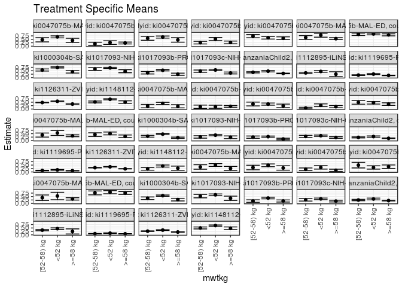

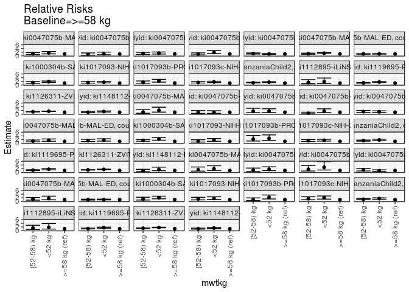

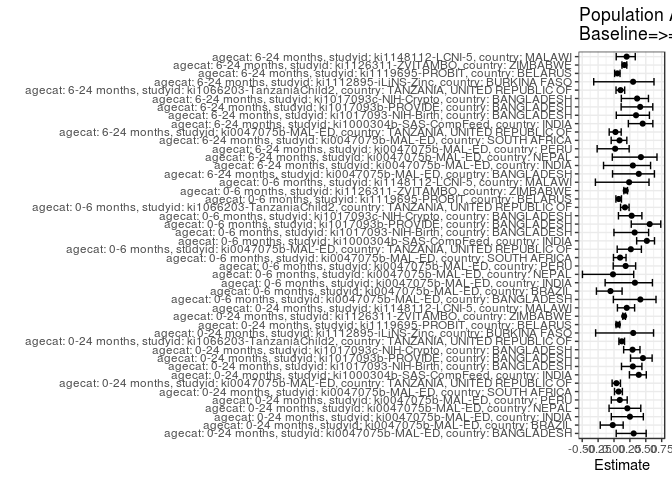

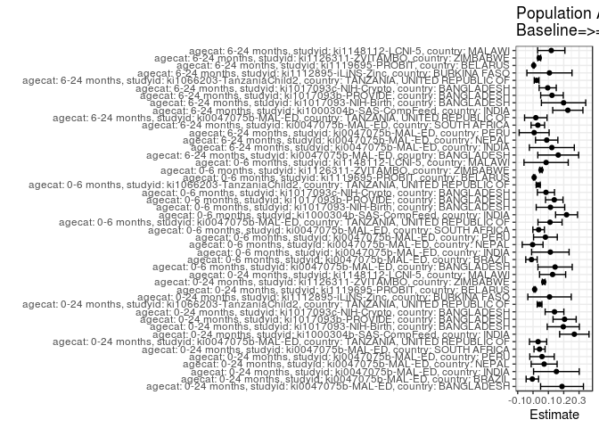

## Results Table

### Parameter: TSM

| agecat | studyid | country | intervention_level | baseline_level | estimate | ci_lower | ci_upper |
| --- | --- | --- | --- | --- | --- | --- | --- |
| 0-24 months | ki0047075b-MAL-ED | BANGLADESH | >=58 kg | NA | 0.4213260 | 0.2687204 | 0.5739316 |
| 0-24 months | ki0047075b-MAL-ED | BANGLADESH | <52 kg | NA | 0.6763716 | 0.6027385 | 0.7500048 |
| 0-24 months | ki0047075b-MAL-ED | BANGLADESH | [52-58) kg | NA | 0.4659037 | 0.3132202 | 0.6185871 |
| 0-24 months | ki0047075b-MAL-ED | BRAZIL | >=58 kg | NA | 0.2307692 | 0.1615571 | 0.2999813 |
| 0-24 months | ki0047075b-MAL-ED | BRAZIL | <52 kg | NA | 0.2619048 | 0.1286336 | 0.3951759 |
| 0-24 months | ki0047075b-MAL-ED | BRAZIL | [52-58) kg | NA | 0.1666667 | 0.0446511 | 0.2886823 |
| 0-24 months | ki0047075b-MAL-ED | INDIA | >=58 kg | NA | 0.4550787 | 0.2916248 | 0.6185326 |
| 0-24 months | ki0047075b-MAL-ED | INDIA | <52 kg | NA | 0.6630146 | 0.5869871 | 0.7390420 |
| 0-24 months | ki0047075b-MAL-ED | INDIA | [52-58) kg | NA | 0.5731055 | 0.4300192 | 0.7161918 |
| 0-24 months | ki0047075b-MAL-ED | NEPAL | >=58 kg | NA | 0.2721054 | 0.1717068 | 0.3725039 |
| 0-24 months | ki0047075b-MAL-ED | NEPAL | <52 kg | NA | 0.5153976 | 0.4012655 | 0.6295298 |
| 0-24 months | ki0047075b-MAL-ED | NEPAL | [52-58) kg | NA | 0.2580993 | 0.1623258 | 0.3538727 |
| 0-24 months | ki0047075b-MAL-ED | PERU | >=58 kg | NA | 0.5828289 | 0.4850265 | 0.6806314 |
| 0-24 months | ki0047075b-MAL-ED | PERU | <52 kg | NA | 0.6098877 | 0.5198192 | 0.6999563 |
| 0-24 months | ki0047075b-MAL-ED | PERU | [52-58) kg | NA | 0.7300417 | 0.6131532 | 0.8469302 |
| 0-24 months | ki0047075b-MAL-ED | SOUTH AFRICA | >=58 kg | NA | 0.5463918 | 0.4762066 | 0.6165769 |
| 0-24 months | ki0047075b-MAL-ED | SOUTH AFRICA | <52 kg | NA | 0.8000000 | 0.6565987 | 0.9434013 |
| 0-24 months | ki0047075b-MAL-ED | SOUTH AFRICA | [52-58) kg | NA | 0.6304348 | 0.4906884 | 0.7701812 |
| 0-24 months | ki0047075b-MAL-ED | TANZANIA, UNITED REPUBLIC OF | >=58 kg | NA | 0.8265306 | 0.7514158 | 0.9016455 |
| 0-24 months | ki0047075b-MAL-ED | TANZANIA, UNITED REPUBLIC OF | <52 kg | NA | 0.8888889 | 0.8268616 | 0.9509162 |
| 0-24 months | ki0047075b-MAL-ED | TANZANIA, UNITED REPUBLIC OF | [52-58) kg | NA | 0.8644068 | 0.7768782 | 0.9519354 |
| 0-24 months | ki1000304b-SAS-CompFeed | INDIA | >=58 kg | NA | 0.4217568 | 0.3325481 | 0.5109655 |
| 0-24 months | ki1000304b-SAS-CompFeed | INDIA | <52 kg | NA | 0.7431894 | 0.7003517 | 0.7860272 |
| 0-24 months | ki1000304b-SAS-CompFeed | INDIA | [52-58) kg | NA | 0.5549121 | 0.4782364 | 0.6315877 |
| 0-24 months | ki1017093-NIH-Birth | BANGLADESH | >=58 kg | NA | 0.4674401 | 0.3545922 | 0.5802880 |
| 0-24 months | ki1017093-NIH-Birth | BANGLADESH | <52 kg | NA | 0.7078724 | 0.6658670 | 0.7498778 |
| 0-24 months | ki1017093-NIH-Birth | BANGLADESH | [52-58) kg | NA | 0.6263420 | 0.5279871 | 0.7246969 |
| 0-24 months | ki1017093b-PROVIDE | BANGLADESH | >=58 kg | NA | 0.2456091 | 0.1652091 | 0.3260090 |
| 0-24 months | ki1017093b-PROVIDE | BANGLADESH | <52 kg | NA | 0.5352339 | 0.4880764 | 0.5823913 |
| 0-24 months | ki1017093b-PROVIDE | BANGLADESH | [52-58) kg | NA | 0.3556375 | 0.2660065 | 0.4452685 |

[output cut: 108 more lines]

### Parameter: E(Y)

| agecat | studyid | country | intervention_level | baseline_level | estimate | ci_lower | ci_upper |
| --- | --- | --- | --- | --- | --- | --- | --- |
| 0-24 months | ki0047075b-MAL-ED | BANGLADESH | NA | NA | 0.6102362 | 0.5501413 | 0.6703311 |
| 0-24 months | ki0047075b-MAL-ED | BRAZIL | NA | NA | 0.2262443 | 0.1709568 | 0.2815319 |
| 0-24 months | ki0047075b-MAL-ED | INDIA | NA | NA | 0.6074380 | 0.5457864 | 0.6690897 |
| 0-24 months | ki0047075b-MAL-ED | NEPAL | NA | NA | 0.3445378 | 0.2840363 | 0.4050393 |
| 0-24 months | ki0047075b-MAL-ED | PERU | NA | NA | 0.6413793 | 0.5860858 | 0.6966728 |
| 0-24 months | ki0047075b-MAL-ED | SOUTH AFRICA | NA | NA | 0.5888889 | 0.5300901 | 0.6476877 |
| 0-24 months | ki0047075b-MAL-ED | TANZANIA, UNITED REPUBLIC OF | NA | NA | 0.8593750 | 0.8167072 | 0.9020428 |
| 0-24 months | ki1000304b-SAS-CompFeed | INDIA | NA | NA | 0.6908851 | 0.6500577 | 0.7317124 |
| 0-24 months | ki1017093-NIH-Birth | BANGLADESH | NA | NA | 0.6645469 | 0.6276196 | 0.7014742 |
| 0-24 months | ki1017093b-PROVIDE | BANGLADESH | NA | NA | 0.4514200 | 0.4136828 | 0.4891573 |
| 0-24 months | ki1017093c-NIH-Crypto | BANGLADESH | NA | NA | 0.4794702 | 0.4438115 | 0.5151289 |
| 0-24 months | ki1066203-TanzaniaChild2 | TANZANIA, UNITED REPUBLIC OF | NA | NA | 0.3465136 | 0.3272783 | 0.3657490 |
| 0-24 months | ki1112895-iLiNS-Zinc | BURKINA FASO | NA | NA | 0.3559962 | 0.3060347 | 0.4059578 |
| 0-24 months | ki1119695-PROBIT | BELARUS | NA | NA | 0.1694743 | 0.1504830 | 0.1884655 |
| 0-24 months | ki1126311-ZVITAMBO | ZIMBABWE | NA | NA | 0.4356480 | 0.4264663 | 0.4448297 |
| 0-24 months | ki1148112-LCNI-5 | MALAWI | NA | NA | 0.6360382 | 0.6034429 | 0.6686335 |
| 0-6 months | ki0047075b-MAL-ED | BANGLADESH | NA | NA | 0.3464567 | 0.2878227 | 0.4050907 |
| 0-6 months | ki0047075b-MAL-ED | BRAZIL | NA | NA | 0.1855204 | 0.1341547 | 0.2368860 |
| 0-6 months | ki0047075b-MAL-ED | INDIA | NA | NA | 0.3429752 | 0.2830428 | 0.4029076 |
| 0-6 months | ki0047075b-MAL-ED | NEPAL | NA | NA | 0.1722689 | 0.1241936 | 0.2203442 |
| 0-6 months | ki0047075b-MAL-ED | PERU | NA | NA | 0.4413793 | 0.3841309 | 0.4986278 |
| 0-6 months | ki0047075b-MAL-ED | SOUTH AFRICA | NA | NA | 0.3814815 | 0.3234338 | 0.4395292 |
| 0-6 months | ki0047075b-MAL-ED | TANZANIA, UNITED REPUBLIC OF | NA | NA | 0.4179688 | 0.3574314 | 0.4785061 |
| 0-6 months | ki1000304b-SAS-CompFeed | INDIA | NA | NA | 0.4228987 | 0.3938571 | 0.4519404 |
| 0-6 months | ki1017093-NIH-Birth | BANGLADESH | NA | NA | 0.3497615 | 0.3124631 | 0.3870600 |
| 0-6 months | ki1017093b-PROVIDE | BANGLADESH | NA | NA | 0.2466368 | 0.2139486 | 0.2793250 |
| 0-6 months | ki1017093c-NIH-Crypto | BANGLADESH | NA | NA | 0.3033113 | 0.2704998 | 0.3361228 |
| 0-6 months | ki1066203-TanzaniaChild2 | TANZANIA, UNITED REPUBLIC OF | NA | NA | 0.1943027 | 0.1783091 | 0.2102964 |
| 0-6 months | ki1119695-PROBIT | BELARUS | NA | NA | 0.0970084 | 0.0840167 | 0.1100001 |
| 0-6 months | ki1126311-ZVITAMBO | ZIMBABWE | NA | NA | 0.2815517 | 0.2732174 | 0.2898859 |
| 0-6 months | ki1148112-LCNI-5 | MALAWI | NA | NA | 0.3579336 | 0.3007518 | 0.4151153 |
| 6-24 months | ki0047075b-MAL-ED | BANGLADESH | NA | NA | 0.4213836 | 0.3443902 | 0.4983771 |
| 6-24 months | ki0047075b-MAL-ED | INDIA | NA | NA | 0.4129032 | 0.3351414 | 0.4906651 |
| 6-24 months | ki0047075b-MAL-ED | NEPAL | NA | NA | 0.2102564 | 0.1529155 | 0.2675974 |
| 6-24 months | ki0047075b-MAL-ED | PERU | NA | NA | 0.3918919 | 0.3129763 | 0.4708075 |
| 6-24 months | ki0047075b-MAL-ED | SOUTH AFRICA | NA | NA | 0.3589744 | 0.2834562 | 0.4344926 |
| 6-24 months | ki0047075b-MAL-ED | TANZANIA, UNITED REPUBLIC OF | NA | NA | 0.7793103 | 0.7115754 | 0.8470453 |
| 6-24 months | ki1000304b-SAS-CompFeed | INDIA | NA | NA | 0.5024691 | 0.4579693 | 0.5469690 |
| 6-24 months | ki1017093-NIH-Birth | BANGLADESH | NA | NA | 0.5739130 | 0.5216565 | 0.6261696 |
| 6-24 months | ki1017093b-PROVIDE | BANGLADESH | NA | NA | 0.2997812 | 0.2577294 | 0.3418330 |
| 6-24 months | ki1017093c-NIH-Crypto | BANGLADESH | NA | NA | 0.2628458 | 0.2244546 | 0.3012371 |
| 6-24 months | ki1066203-TanzaniaChild2 | TANZANIA, UNITED REPUBLIC OF | NA | NA | 0.2277354 | 0.2069978 | 0.2484730 |
| 6-24 months | ki1112895-iLiNS-Zinc | BURKINA FASO | NA | NA | 0.3559962 | 0.3060347 | 0.4059578 |
| 6-24 months | ki1119695-PROBIT | BELARUS | NA | NA | 0.0803025 | 0.0658938 | 0.0947113 |
| 6-24 months | ki1126311-ZVITAMBO | ZIMBABWE | NA | NA | 0.2460554 | 0.2359900 | 0.2561209 |
| 6-24 months | ki1148112-LCNI-5 | MALAWI | NA | NA | 0.5989011 | 0.5632737 | 0.6345285 |

### Parameter: RR

| agecat | studyid | country | intervention_level | baseline_level | estimate | ci_lower | ci_upper |
| --- | --- | --- | --- | --- | --- | --- | --- |
| 0-24 months | ki0047075b-MAL-ED | BANGLADESH | >=58 kg | >=58 kg | 1.0000000 | 1.0000000 | 1.000000 |
| 0-24 months | ki0047075b-MAL-ED | BANGLADESH | <52 kg | >=58 kg | 1.6053402 | 1.0973894 | 2.348407 |
| 0-24 months | ki0047075b-MAL-ED | BANGLADESH | [52-58) kg | >=58 kg | 1.1058032 | 0.6792111 | 1.800325 |
| 0-24 months | ki0047075b-MAL-ED | BRAZIL | >=58 kg | >=58 kg | 1.0000000 | 1.0000000 | 1.000000 |
| 0-24 months | ki0047075b-MAL-ED | BRAZIL | <52 kg | >=58 kg | 1.1349206 | 0.6287002 | 2.048743 |
| 0-24 months | ki0047075b-MAL-ED | BRAZIL | [52-58) kg | >=58 kg | 0.7222222 | 0.3274012 | 1.593167 |
| 0-24 months | ki0047075b-MAL-ED | INDIA | >=58 kg | >=58 kg | 1.0000000 | 1.0000000 | 1.000000 |
| 0-24 months | ki0047075b-MAL-ED | INDIA | <52 kg | >=58 kg | 1.4569230 | 0.9990835 | 2.124572 |
| 0-24 months | ki0047075b-MAL-ED | INDIA | [52-58) kg | >=58 kg | 1.2593548 | 0.8128867 | 1.951040 |
| 0-24 months | ki0047075b-MAL-ED | NEPAL | >=58 kg | >=58 kg | 1.0000000 | 1.0000000 | 1.000000 |
| 0-24 months | ki0047075b-MAL-ED | NEPAL | <52 kg | >=58 kg | 1.8941104 | 1.2300588 | 2.916653 |
| 0-24 months | ki0047075b-MAL-ED | NEPAL | [52-58) kg | >=58 kg | 0.9485269 | 0.5610099 | 1.603721 |
| 0-24 months | ki0047075b-MAL-ED | PERU | >=58 kg | >=58 kg | 1.0000000 | 1.0000000 | 1.000000 |
| 0-24 months | ki0047075b-MAL-ED | PERU | <52 kg | >=58 kg | 1.0464267 | 0.8356270 | 1.310404 |
| 0-24 months | ki0047075b-MAL-ED | PERU | [52-58) kg | >=58 kg | 1.2525831 | 0.9932572 | 1.579616 |
| 0-24 months | ki0047075b-MAL-ED | SOUTH AFRICA | >=58 kg | >=58 kg | 1.0000000 | 1.0000000 | 1.000000 |
| 0-24 months | ki0047075b-MAL-ED | SOUTH AFRICA | <52 kg | >=58 kg | 1.4641509 | 1.1743924 | 1.825402 |
| 0-24 months | ki0047075b-MAL-ED | SOUTH AFRICA | [52-58) kg | >=58 kg | 1.1538146 | 0.8930418 | 1.490734 |
| 0-24 months | ki0047075b-MAL-ED | TANZANIA, UNITED REPUBLIC OF | >=58 kg | >=58 kg | 1.0000000 | 1.0000000 | 1.000000 |
| 0-24 months | ki0047075b-MAL-ED | TANZANIA, UNITED REPUBLIC OF | <52 kg | >=58 kg | 1.0754458 | 0.9590191 | 1.206007 |
| 0-24 months | ki0047075b-MAL-ED | TANZANIA, UNITED REPUBLIC OF | [52-58) kg | >=58 kg | 1.0458255 | 0.9127860 | 1.198256 |
| 0-24 months | ki1000304b-SAS-CompFeed | INDIA | >=58 kg | >=58 kg | 1.0000000 | 1.0000000 | 1.000000 |
| 0-24 months | ki1000304b-SAS-CompFeed | INDIA | <52 kg | >=58 kg | 1.7621280 | 1.4263218 | 2.176995 |
| 0-24 months | ki1000304b-SAS-CompFeed | INDIA | [52-58) kg | >=58 kg | 1.3157158 | 0.9409308 | 1.839783 |
| 0-24 months | ki1017093-NIH-Birth | BANGLADESH | >=58 kg | >=58 kg | 1.0000000 | 1.0000000 | 1.000000 |
| 0-24 months | ki1017093-NIH-Birth | BANGLADESH | <52 kg | >=58 kg | 1.5143596 | 1.1808903 | 1.941997 |
| 0-24 months | ki1017093-NIH-Birth | BANGLADESH | [52-58) kg | >=58 kg | 1.3399406 | 1.0052278 | 1.786104 |
| 0-24 months | ki1017093b-PROVIDE | BANGLADESH | >=58 kg | >=58 kg | 1.0000000 | 1.0000000 | 1.000000 |
| 0-24 months | ki1017093b-PROVIDE | BANGLADESH | <52 kg | >=58 kg | 2.1792107 | 1.5525046 | 3.058902 |
| 0-24 months | ki1017093b-PROVIDE | BANGLADESH | [52-58) kg | >=58 kg | 1.4479821 | 0.9579985 | 2.188576 |

[output cut: 108 more lines]

### Parameter: PAR

| agecat | studyid | country | intervention_level | baseline_level | estimate | ci_lower | ci_upper |
| --- | --- | --- | --- | --- | --- | --- | --- |
| 0-24 months | ki0047075b-MAL-ED | BANGLADESH | >=58 kg | NA | 0.1889102 | 0.0492120 | 0.3286084 |
| 0-24 months | ki0047075b-MAL-ED | BRAZIL | >=58 kg | NA | -0.0045249 | -0.0451180 | 0.0360682 |
| 0-24 months | ki0047075b-MAL-ED | INDIA | >=58 kg | NA | 0.1523593 | 0.0035521 | 0.3011666 |
| 0-24 months | ki0047075b-MAL-ED | NEPAL | >=58 kg | NA | 0.0724325 | -0.0121012 | 0.1569661 |
| 0-24 months | ki0047075b-MAL-ED | PERU | >=58 kg | NA | 0.0585504 | -0.0210667 | 0.1381675 |
| 0-24 months | ki0047075b-MAL-ED | SOUTH AFRICA | >=58 kg | NA | 0.0424971 | 0.0063797 | 0.0786146 |
| 0-24 months | ki0047075b-MAL-ED | TANZANIA, UNITED REPUBLIC OF | >=58 kg | NA | 0.0328444 | -0.0232176 | 0.0889064 |
| 0-24 months | ki1000304b-SAS-CompFeed | INDIA | >=58 kg | NA | 0.2691283 | 0.1734345 | 0.3648221 |
| 0-24 months | ki1017093-NIH-Birth | BANGLADESH | >=58 kg | NA | 0.1971068 | 0.0924007 | 0.3018129 |
| 0-24 months | ki1017093b-PROVIDE | BANGLADESH | >=58 kg | NA | 0.2058110 | 0.1304060 | 0.2812159 |
| 0-24 months | ki1017093c-NIH-Crypto | BANGLADESH | >=58 kg | NA | 0.1399621 | 0.0790026 | 0.2009217 |
| 0-24 months | ki1066203-TanzaniaChild2 | TANZANIA, UNITED REPUBLIC OF | >=58 kg | NA | 0.0425468 | 0.0271522 | 0.0579414 |
| 0-24 months | ki1112895-iLiNS-Zinc | BURKINA FASO | >=58 kg | NA | 0.1076389 | -0.0338924 | 0.2491702 |
| 0-24 months | ki1119695-PROBIT | BELARUS | >=58 kg | NA | 0.0104835 | 0.0058675 | 0.0150995 |
| 0-24 months | ki1126311-ZVITAMBO | ZIMBABWE | >=58 kg | NA | 0.0695921 | 0.0606090 | 0.0785752 |
| 0-24 months | ki1148112-LCNI-5 | MALAWI | >=58 kg | NA | 0.1275159 | 0.0423558 | 0.2126760 |
| 0-6 months | ki0047075b-MAL-ED | BANGLADESH | >=58 kg | NA | 0.1437073 | 0.0319687 | 0.2554459 |
| 0-6 months | ki0047075b-MAL-ED | BRAZIL | >=58 kg | NA | -0.0102838 | -0.0475484 | 0.0269807 |
| 0-6 months | ki0047075b-MAL-ED | INDIA | >=58 kg | NA | 0.1128661 | -0.0093035 | 0.2350357 |
| 0-6 months | ki0047075b-MAL-ED | NEPAL | >=58 kg | NA | -0.0027311 | -0.0705017 | 0.0650396 |
| 0-6 months | ki0047075b-MAL-ED | PERU | >=58 kg | NA | 0.0807500 | 0.0034228 | 0.1580771 |
| 0-6 months | ki0047075b-MAL-ED | SOUTH AFRICA | >=58 kg | NA | 0.0365779 | -0.0010412 | 0.0741971 |
| 0-6 months | ki0047075b-MAL-ED | TANZANIA, UNITED REPUBLIC OF | >=58 kg | NA | 0.1107527 | 0.0321799 | 0.1893256 |
| 0-6 months | ki1000304b-SAS-CompFeed | INDIA | >=58 kg | NA | 0.2185406 | 0.1469773 | 0.2901039 |
| 0-6 months | ki1017093-NIH-Birth | BANGLADESH | >=58 kg | NA | 0.1136194 | 0.0207103 | 0.2065285 |
| 0-6 months | ki1017093b-PROVIDE | BANGLADESH | >=58 kg | NA | 0.1384654 | 0.0814572 | 0.1954736 |
| 0-6 months | ki1017093c-NIH-Crypto | BANGLADESH | >=58 kg | NA | 0.0842091 | 0.0285015 | 0.1399168 |
| 0-6 months | ki1066203-TanzaniaChild2 | TANZANIA, UNITED REPUBLIC OF | >=58 kg | NA | 0.0336011 | 0.0204292 | 0.0467730 |
| 0-6 months | ki1119695-PROBIT | BELARUS | >=58 kg | NA | 0.0072333 | 0.0030882 | 0.0113784 |
| 0-6 months | ki1126311-ZVITAMBO | ZIMBABWE | >=58 kg | NA | 0.0518764 | 0.0436969 | 0.0600559 |
| 0-6 months | ki1148112-LCNI-5 | MALAWI | >=58 kg | NA | 0.0852063 | -0.0590172 | 0.2294298 |
| 6-24 months | ki0047075b-MAL-ED | BANGLADESH | >=58 kg | NA | 0.1642408 | 0.0310577 | 0.2974239 |
| 6-24 months | ki0047075b-MAL-ED | INDIA | >=58 kg | NA | 0.1225806 | -0.0239297 | 0.2690910 |
| 6-24 months | ki0047075b-MAL-ED | NEPAL | >=58 kg | NA | 0.0890443 | 0.0162340 | 0.1618546 |
| 6-24 months | ki0047075b-MAL-ED | PERU | >=58 kg | NA | 0.0072571 | -0.0903531 | 0.1048673 |
| 6-24 months | ki0047075b-MAL-ED | SOUTH AFRICA | >=58 kg | NA | 0.0312433 | -0.0128063 | 0.0752928 |
| 6-24 months | ki0047075b-MAL-ED | TANZANIA, UNITED REPUBLIC OF | >=58 kg | NA | 0.0181163 | -0.0552606 | 0.0914932 |
| 6-24 months | ki1000304b-SAS-CompFeed | INDIA | >=58 kg | NA | 0.2268235 | 0.1283739 | 0.3252731 |
| 6-24 months | ki1017093-NIH-Birth | BANGLADESH | >=58 kg | NA | 0.1990222 | 0.0545555 | 0.3434888 |
| 6-24 months | ki1017093b-PROVIDE | BANGLADESH | >=58 kg | NA | 0.1235026 | 0.0498280 | 0.1971771 |
| 6-24 months | ki1017093c-NIH-Crypto | BANGLADESH | >=58 kg | NA | 0.0955778 | 0.0397635 | 0.1513921 |
| 6-24 months | ki1066203-TanzaniaChild2 | TANZANIA, UNITED REPUBLIC OF | >=58 kg | NA | 0.0233463 | 0.0077892 | 0.0389034 |
| 6-24 months | ki1112895-iLiNS-Zinc | BURKINA FASO | >=58 kg | NA | 0.1069650 | -0.0401566 | 0.2540866 |
| 6-24 months | ki1119695-PROBIT | BELARUS | >=58 kg | NA | 0.0042957 | 0.0010142 | 0.0075772 |
| 6-24 months | ki1126311-ZVITAMBO | ZIMBABWE | >=58 kg | NA | 0.0403375 | 0.0309529 | 0.0497222 |
| 6-24 months | ki1148112-LCNI-5 | MALAWI | >=58 kg | NA | 0.1189405 | 0.0301514 | 0.2077295 |

### Parameter: PAF

| agecat | studyid | country | intervention_level | baseline_level | estimate | ci_lower | ci_upper |
| --- | --- | --- | --- | --- | --- | --- | --- |
| 0-24 months | ki0047075b-MAL-ED | BANGLADESH | >=58 kg | NA | 0.3095690 | 0.0348999 | 0.5060668 |
| 0-24 months | ki0047075b-MAL-ED | BRAZIL | >=58 kg | NA | -0.0200000 | -0.2161373 | 0.1445045 |
| 0-24 months | ki0047075b-MAL-ED | INDIA | >=58 kg | NA | 0.2508229 | -0.0422622 | 0.4614921 |
| 0-24 months | ki0047075b-MAL-ED | NEPAL | >=58 kg | NA | 0.2102308 | -0.0777194 | 0.4212450 |
| 0-24 months | ki0047075b-MAL-ED | PERU | >=58 kg | NA | 0.0912882 | -0.0421828 | 0.2076658 |
| 0-24 months | ki0047075b-MAL-ED | SOUTH AFRICA | >=58 kg | NA | 0.0721649 | 0.0080152 | 0.1321663 |
| 0-24 months | ki0047075b-MAL-ED | TANZANIA, UNITED REPUBLIC OF | >=58 kg | NA | 0.0382189 | -0.0295971 | 0.1015681 |
| 0-24 months | ki1000304b-SAS-CompFeed | INDIA | >=58 kg | NA | 0.3895413 | 0.2424104 | 0.5080980 |
| 0-24 months | ki1017093-NIH-Birth | BANGLADESH | >=58 kg | NA | 0.2966033 | 0.1178454 | 0.4391381 |
| 0-24 months | ki1017093b-PROVIDE | BANGLADESH | >=58 kg | NA | 0.4559190 | 0.2603683 | 0.5997682 |
| 0-24 months | ki1017093c-NIH-Crypto | BANGLADESH | >=58 kg | NA | 0.2919100 | 0.1519480 | 0.4087727 |
| 0-24 months | ki1066203-TanzaniaChild2 | TANZANIA, UNITED REPUBLIC OF | >=58 kg | NA | 0.1227854 | 0.0772529 | 0.1660711 |
| 0-24 months | ki1112895-iLiNS-Zinc | BURKINA FASO | >=58 kg | NA | 0.3023597 | -0.2889504 | 0.6224044 |
| 0-24 months | ki1119695-PROBIT | BELARUS | >=58 kg | NA | 0.0618589 | 0.0320157 | 0.0907820 |
| 0-24 months | ki1126311-ZVITAMBO | ZIMBABWE | >=58 kg | NA | 0.1597439 | 0.1387882 | 0.1801896 |
| 0-24 months | ki1148112-LCNI-5 | MALAWI | >=58 kg | NA | 0.2004847 | 0.0539216 | 0.3243427 |
| 0-6 months | ki0047075b-MAL-ED | BANGLADESH | >=58 kg | NA | 0.4147914 | -0.0099816 | 0.6609155 |
| 0-6 months | ki0047075b-MAL-ED | BRAZIL | >=58 kg | NA | -0.0554324 | -0.2763152 | 0.1272238 |
| 0-6 months | ki0047075b-MAL-ED | INDIA | >=58 kg | NA | 0.3290795 | -0.1394314 | 0.6049483 |
| 0-6 months | ki0047075b-MAL-ED | NEPAL | >=58 kg | NA | -0.0158537 | -0.4962710 | 0.3103130 |
| 0-6 months | ki0047075b-MAL-ED | PERU | >=58 kg | NA | 0.1829491 | -0.0122506 | 0.3405070 |
| 0-6 months | ki0047075b-MAL-ED | SOUTH AFRICA | >=58 kg | NA | 0.0958839 | -0.0085551 | 0.1895079 |
| 0-6 months | ki0047075b-MAL-ED | TANZANIA, UNITED REPUBLIC OF | >=58 kg | NA | 0.2649785 | 0.0504394 | 0.4310457 |
| 0-6 months | ki1000304b-SAS-CompFeed | INDIA | >=58 kg | NA | 0.5167681 | 0.3563466 | 0.6372068 |
| 0-6 months | ki1017093-NIH-Birth | BANGLADESH | >=58 kg | NA | 0.3248483 | -0.0008381 | 0.5445519 |
| 0-6 months | ki1017093b-PROVIDE | BANGLADESH | >=58 kg | NA | 0.5614142 | 0.2714694 | 0.7359651 |
| 0-6 months | ki1017093c-NIH-Crypto | BANGLADESH | >=58 kg | NA | 0.2776327 | 0.0700493 | 0.4388794 |
| 0-6 months | ki1066203-TanzaniaChild2 | TANZANIA, UNITED REPUBLIC OF | >=58 kg | NA | 0.1729316 | 0.1032762 | 0.2371763 |
| 0-6 months | ki1119695-PROBIT | BELARUS | >=58 kg | NA | 0.0745635 | 0.0299067 | 0.1171647 |
| 0-6 months | ki1126311-ZVITAMBO | ZIMBABWE | >=58 kg | NA | 0.1842519 | 0.1548802 | 0.2126027 |
| 0-6 months | ki1148112-LCNI-5 | MALAWI | >=58 kg | NA | 0.2380506 | -0.2925147 | 0.5508238 |
| 6-24 months | ki0047075b-MAL-ED | BANGLADESH | >=58 kg | NA | 0.3897655 | -0.0228150 | 0.6359203 |
| 6-24 months | ki0047075b-MAL-ED | INDIA | >=58 kg | NA | 0.2968750 | -0.1645763 | 0.5754810 |
| 6-24 months | ki0047075b-MAL-ED | NEPAL | >=58 kg | NA | 0.4235033 | -0.0266294 | 0.6762723 |
| 6-24 months | ki0047075b-MAL-ED | PERU | >=58 kg | NA | 0.0185182 | -0.2650250 | 0.2385078 |
| 6-24 months | ki0047075b-MAL-ED | SOUTH AFRICA | >=58 kg | NA | 0.0870348 | -0.0443387 | 0.2018821 |
| 6-24 months | ki0047075b-MAL-ED | TANZANIA, UNITED REPUBLIC OF | >=58 kg | NA | 0.0232466 | -0.0757380 | 0.1131230 |
| 6-24 months | ki1000304b-SAS-CompFeed | INDIA | >=58 kg | NA | 0.4514178 | 0.2258007 | 0.6112855 |
| 6-24 months | ki1017093-NIH-Birth | BANGLADESH | >=58 kg | NA | 0.3467811 | 0.0360739 | 0.5573365 |
| 6-24 months | ki1017093b-PROVIDE | BANGLADESH | >=58 kg | NA | 0.4119757 | 0.1122986 | 0.6104855 |
| 6-24 months | ki1017093c-NIH-Crypto | BANGLADESH | >=58 kg | NA | 0.3636269 | 0.1152284 | 0.5422879 |
| 6-24 months | ki1066203-TanzaniaChild2 | TANZANIA, UNITED REPUBLIC OF | >=58 kg | NA | 0.1025150 | 0.0318592 | 0.1680143 |
| 6-24 months | ki1112895-iLiNS-Zinc | BURKINA FASO | >=58 kg | NA | 0.3004666 | -0.3190974 | 0.6290289 |
| 6-24 months | ki1119695-PROBIT | BELARUS | >=58 kg | NA | 0.0534939 | 0.0099479 | 0.0951247 |
| 6-24 months | ki1126311-ZVITAMBO | ZIMBABWE | >=58 kg | NA | 0.1639368 | 0.1251924 | 0.2009652 |
| 6-24 months | ki1148112-LCNI-5 | MALAWI | >=58 kg | NA | 0.1985979 | 0.0349480 | 0.3344966 |